# Red Wine Exploratory Data Analysis by Vijin

This report explores a data set of Red Wine quality containing 1,599 red wines with 11 variables on the chemical properties of the wine.At least 3 wine experts rated the quality of each wine, providing a rating between 0 (very bad) and 10 (very excellent).

## Summary of dataset

```
## 'data.frame':    1599 obs. of  13 variables:
##  $ X                   : int  1 2 3 4 5 6 7 8 9 10 ...
##  $ fixed.acidity       : num  7.4 7.8 7.8 11.2 7.4 7.4 7.9 7.3 7.8 7.5 ...
##  $ volatile.acidity    : num  0.7 0.88 0.76 0.28 0.7 0.66 0.6 0.65 0.58 0.5 ...
##  $ citric.acid         : num  0 0 0.04 0.56 0 0 0.06 0 0.02 0.36 ...
##  $ residual.sugar      : num  1.9 2.6 2.3 1.9 1.9 1.8 1.6 1.2 2 6.1 ...
##  $ chlorides           : num  0.076 0.098 0.092 0.075 0.076 0.075 0.069 0.065 0.073 0.071 ...
##  $ free.sulfur.dioxide : num  11 25 15 17 11 13 15 15 9 17 ...
##  $ total.sulfur.dioxide: num  34 67 54 60 34 40 59 21 18 102 ...
##  $ density             : num  0.998 0.997 0.997 0.998 0.998 ...
##  $ pH                  : num  3.51 3.2 3.26 3.16 3.51 3.51 3.3 3.39 3.36 3.35 ...
##  $ sulphates           : num  0.56 0.68 0.65 0.58 0.56 0.56 0.46 0.47 0.57 0.8 ...
##  $ alcohol             : num  9.4 9.8 9.8 9.8 9.4 9.4 9.4 10 9.5 10.5 ...
##  $ quality             : int  5 5 5 6 5 5 5 7 7 5 ...
```

```
##        X          fixed.acidity   volatile.acidity  citric.acid
##  Min.   :   1.0   Min.   : 4.60   Min.   :0.1200   Min.   :0.000
##  1st Qu.: 400.5   1st Qu.: 7.10   1st Qu.:0.3900   1st Qu.:0.090
##  Median : 800.0   Median : 7.90   Median :0.5200   Median :0.260
##  Mean   : 800.0   Mean   : 8.32   Mean   :0.5278   Mean   :0.271
##  3rd Qu.:1199.5   3rd Qu.: 9.20   3rd Qu.:0.6400   3rd Qu.:0.420
##  Max.   :1599.0   Max.   :15.90   Max.   :1.5800   Max.   :1.000
##  residual.sugar     chlorides       free.sulfur.dioxide
##  Min.   : 0.900   Min.   :0.01200   Min.   : 1.00
##  1st Qu.: 1.900   1st Qu.:0.07000   1st Qu.: 7.00
##  Median : 2.200   Median :0.07900   Median :14.00
##  Mean   : 2.539   Mean   :0.08747   Mean   :15.87
##  3rd Qu.: 2.600   3rd Qu.:0.09000   3rd Qu.:21.00
##  Max.   :15.500   Max.   :0.61100   Max.   :72.00
##  total.sulfur.dioxide    density             pH          sulphates
##  Min.   :  6.00       Min.   :0.9901   Min.   :2.740   Min.   :0.3300
##  1st Qu.: 22.00       1st Qu.:0.9956   1st Qu.:3.210   1st Qu.:0.5500
##  Median : 38.00       Median :0.9968   Median :3.310   Median :0.6200
##  Mean   : 46.47       Mean   :0.9967   Mean   :3.311   Mean   :0.6581
##  3rd Qu.: 62.00       3rd Qu.:0.9978   3rd Qu.:3.400   3rd Qu.:0.7300
##  Max.   :289.00       Max.   :1.0037   Max.   :4.010   Max.   :2.0000
##     alcohol         quality
##  Min.   : 8.40   Min.   :3.000
##  1st Qu.: 9.50   1st Qu.:5.000
##  Median :10.20   Median :6.000
##  Mean   :10.42   Mean   :5.636
##  3rd Qu.:11.10   3rd Qu.:6.000
##  Max.   :14.90   Max.   :8.000
```

### Observations from summary

- The maximum quality score given is 8 and the minimum is 3. Majority scores are between 5 and 6. Quality scores are all recorded in whole numbers
- The alochol content for majority of the wines are between 9.5 and 11.10

## Exploring One variable (Quantifying and visualizing individual variables)

### Quality distribution

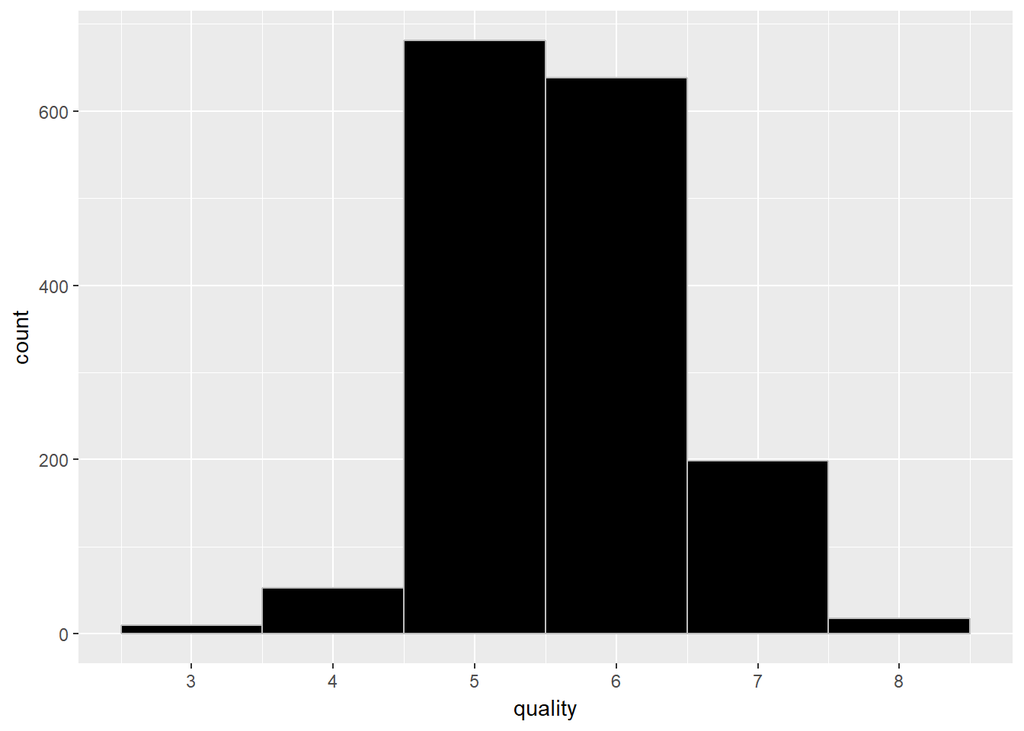

Most of the quality scores are 5 or 6.

### Alcohol percent distribution by Quality

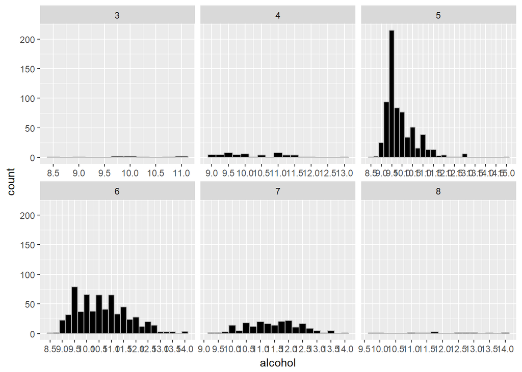

More than 300 wines have alchol percentage around 9.5.

### Sulphate distribution

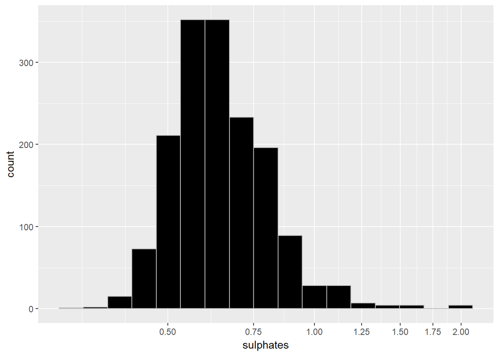

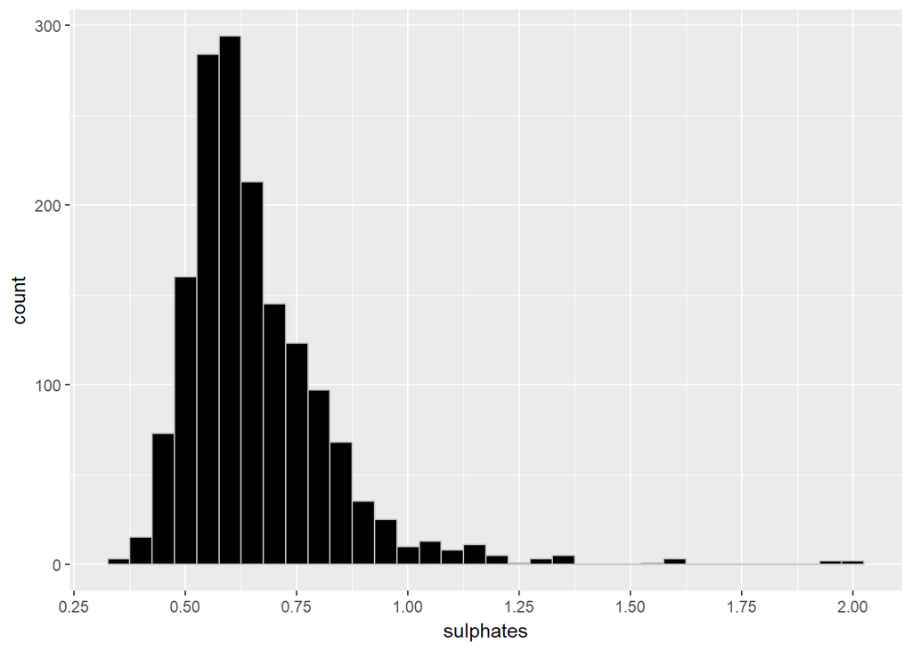

X-axis is transformed using logscale for better distribution. The peak are between 0.5 and 0.75. The distribution is normal

### pH Distribution

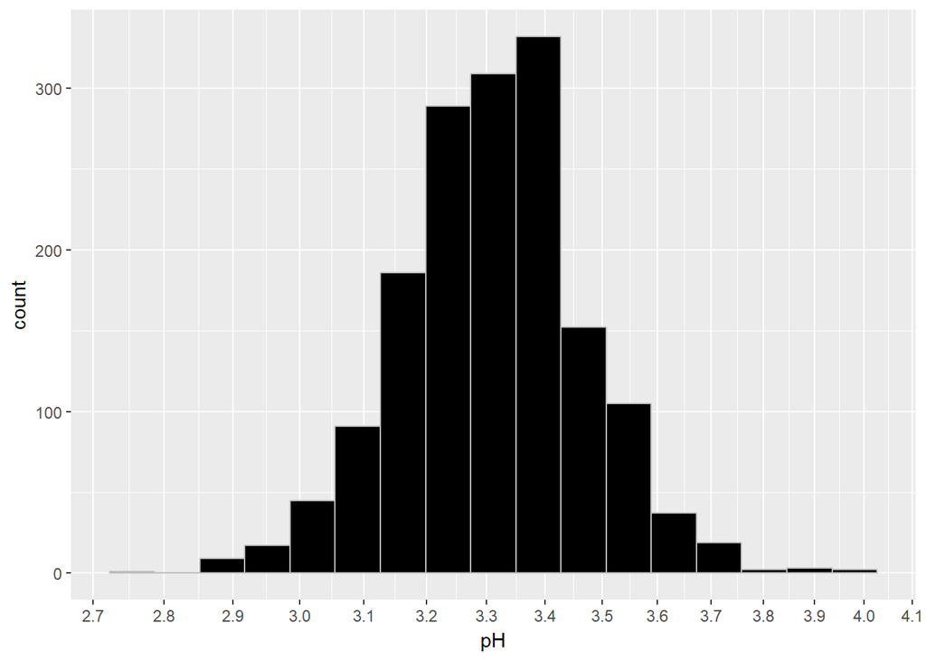

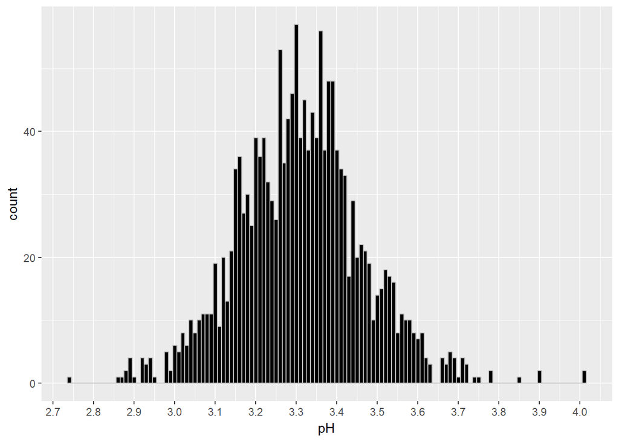

X-axis is transformed using logscale for better distribution. The peak is at 3.4. The distribution is normal

### Density Distribution

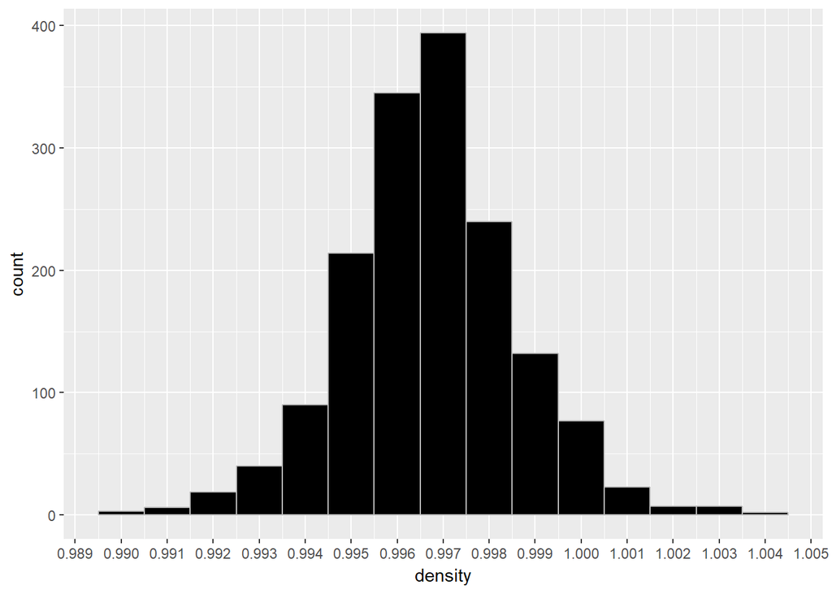

The peak is at 0.997. The distribution is close to normal.

### Sulfur dioxide distribution

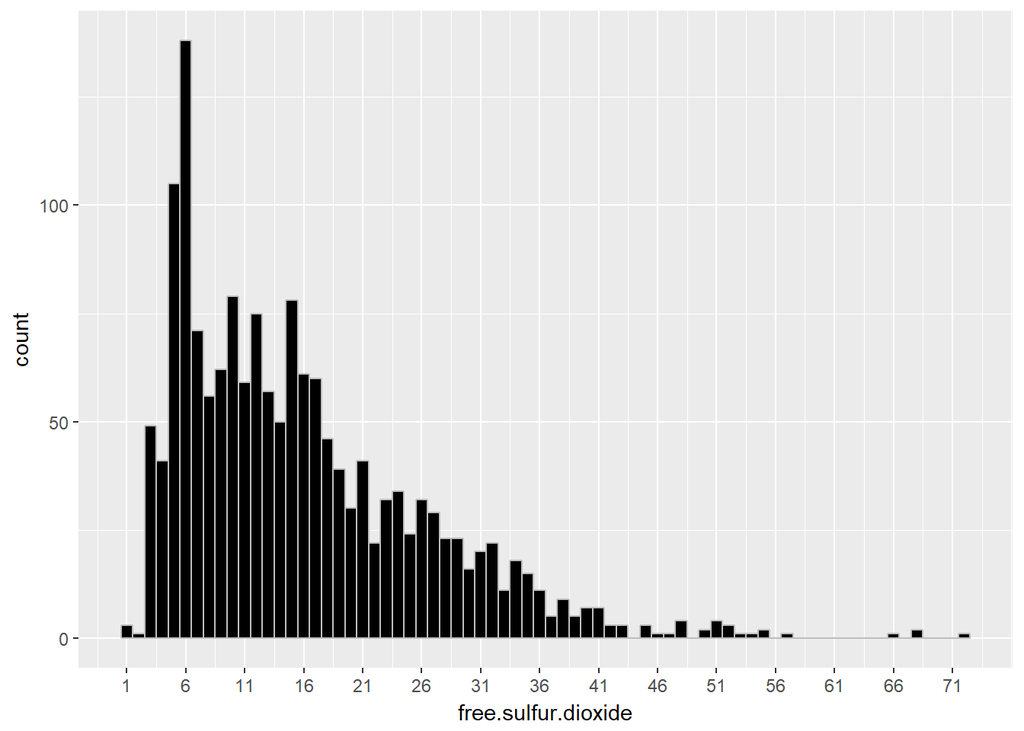

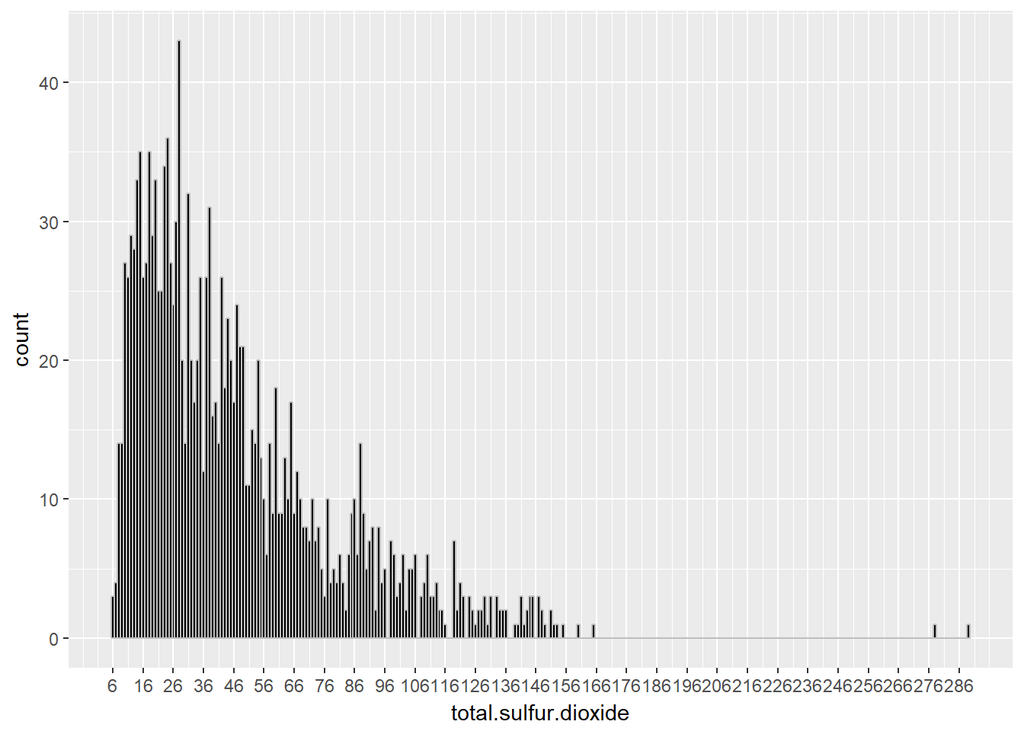

The distribution of free sulfur dioxide and total sulfur dioxide are almost similar

### Cholrides distribution

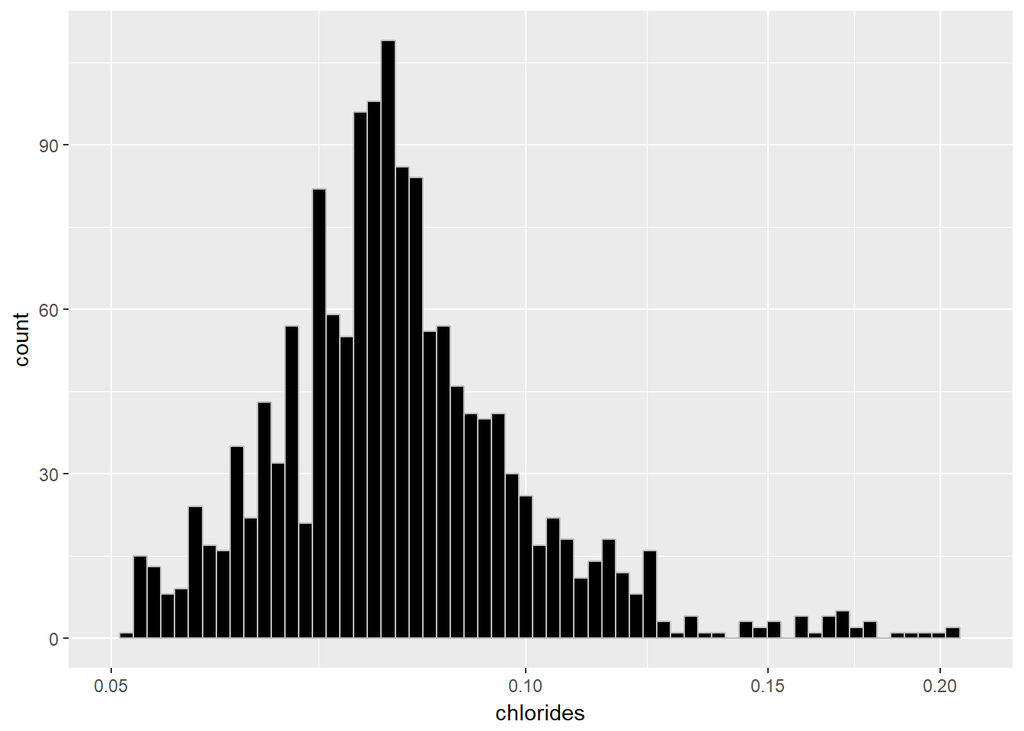

X-axis is transformed using logscale for better distribution.Also, some outliers were also removed. This again resembles a normal distribution.

### Residual sugar distribution

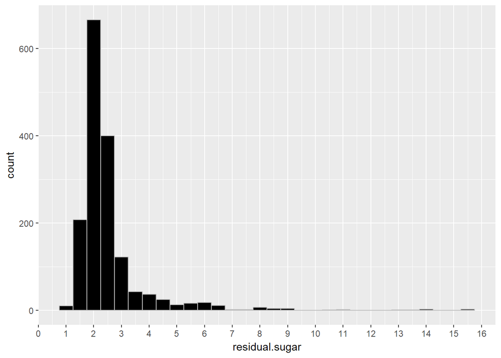

This distribution is skewed with a peak at arond 2.

### Citric acid distribution

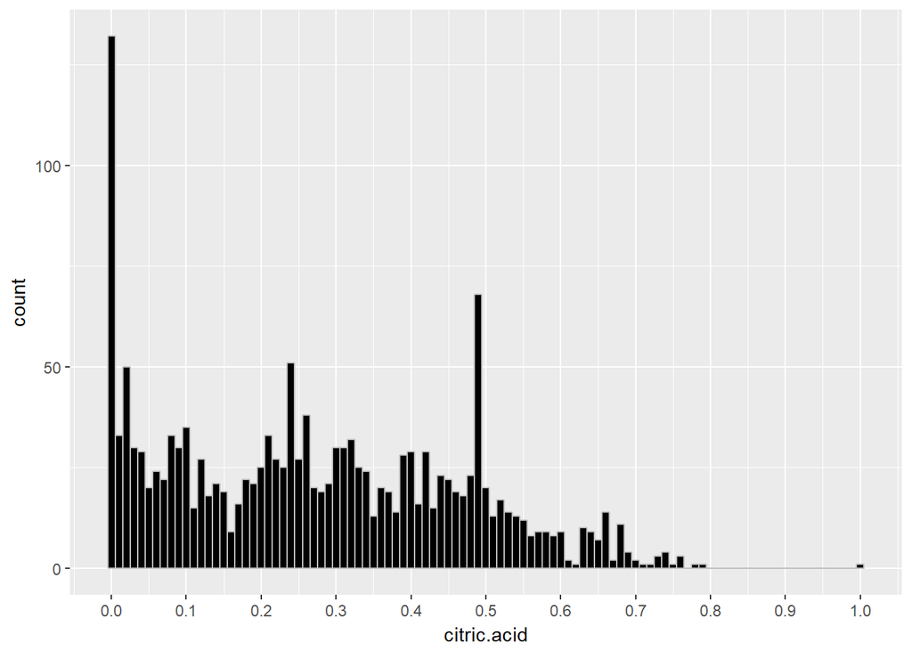

Almost even distributions with peaks at 0 and 0.49

### Acidity distribution

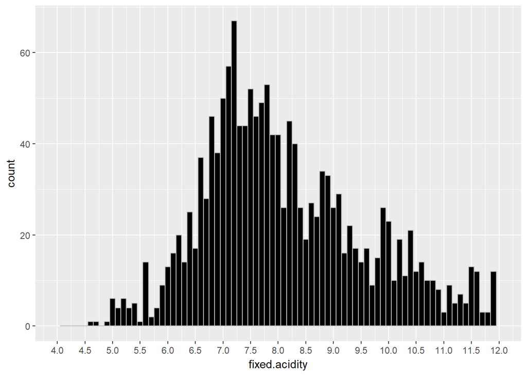

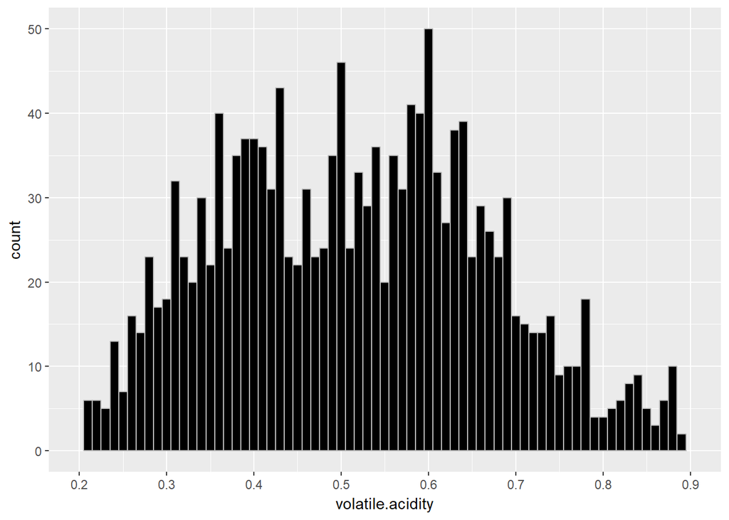

Removed some outliers to create normal distributions for fixed and volatile acidity

#### From our initial analysis of individual variables, no concreate coclusion can be made regarding wine quality

## Exploring multiple variables (Exploring relationship between 2 or more variables)

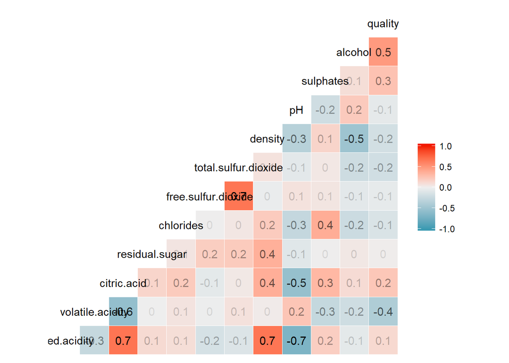

### Analyzing correation between different variables

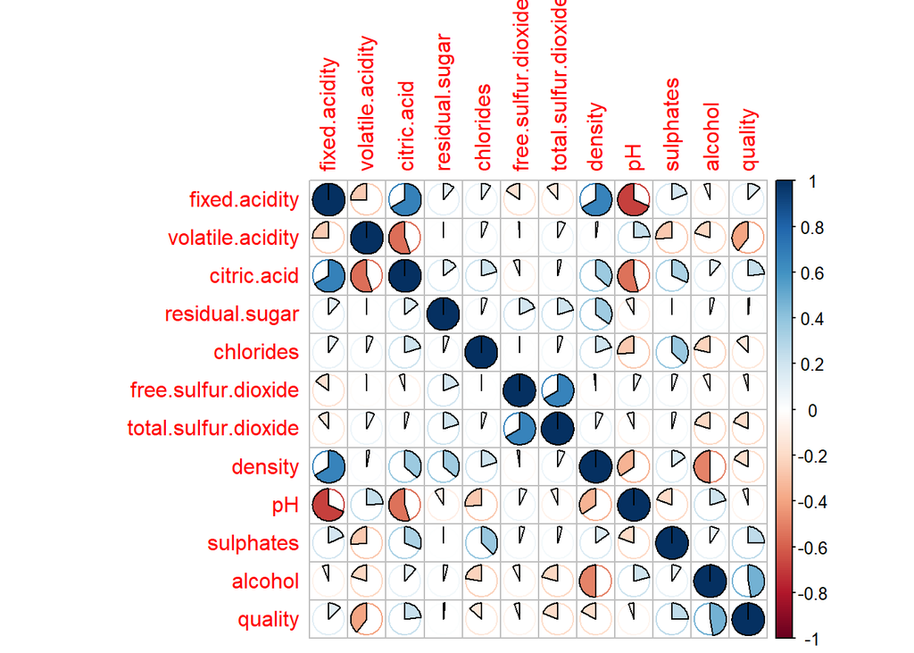

### Understanding the correlation values of quality with alcohol and volatile acidity

```
##
##  Pearson's product-moment correlation
##
## data:  quality and alcohol
## t = 21.639, df = 1597, p-value < 2.2e-16
## alternative hypothesis: true correlation is not equal to 0
## 95 percent confidence interval:
##  0.4373540 0.5132081
## sample estimates:
##       cor
## 0.4761663
```

```
##
##  Pearson's product-moment correlation
##
## data:  quality and volatile.acidity
## t = -16.954, df = 1597, p-value < 2.2e-16
## alternative hypothesis: true correlation is not equal to 0
## 95 percent confidence interval:
##  -0.4313210 -0.3482032
## sample estimates:
##        cor
## -0.3905578
```

### Scatter plot of alcohol vs quality

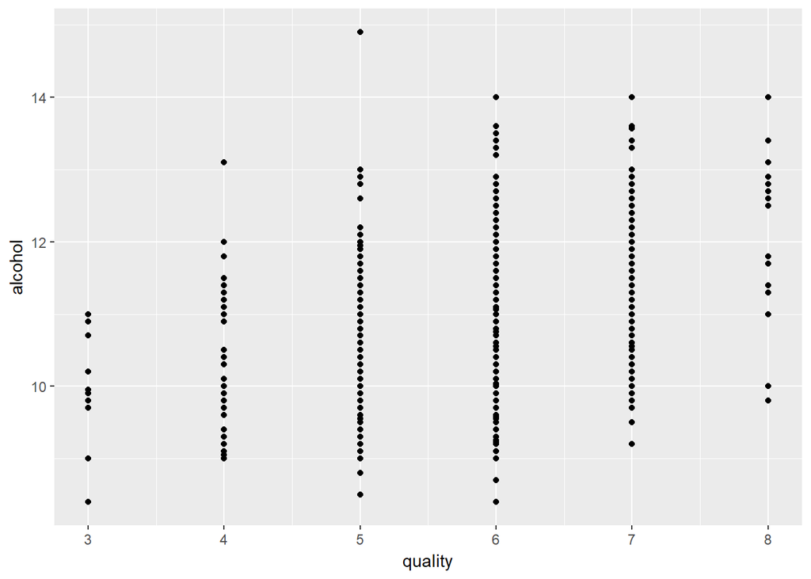

A box plot analysis for the above plot will provide us wth a better understanding

### Box plot of alcohol vs quality

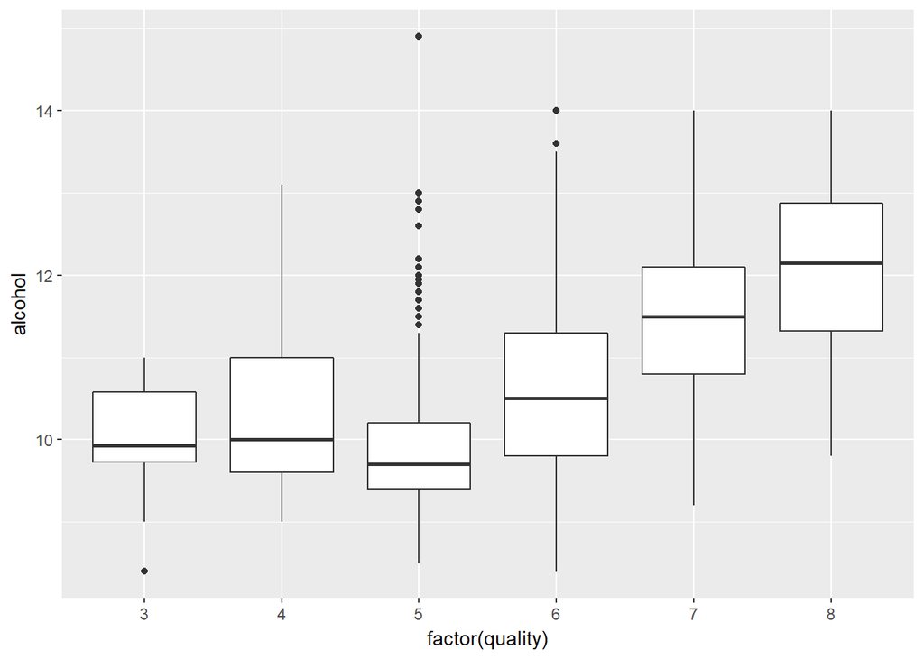

From the above box plot, overlooking the outliers, it looks like for better quality wines, the alcohol content is higher

### Grouping the data set by quality to understand mean values of alcohol

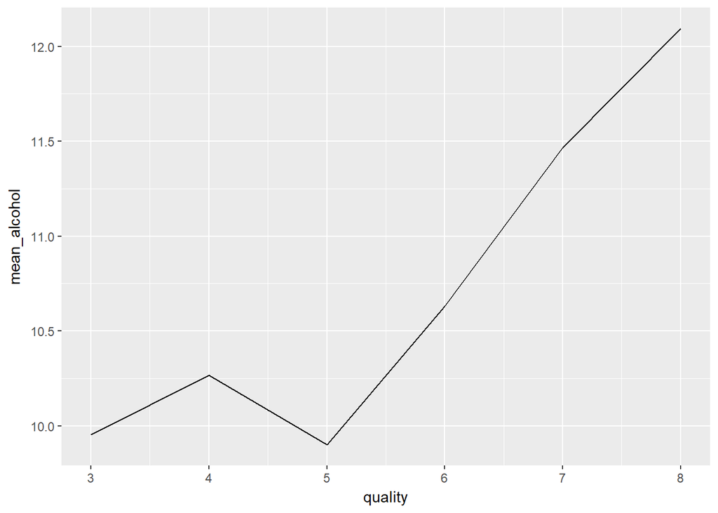

## Understanding if Alcohol percentage along with any other variables other than Volatile acidity influences Quality

### Scatter plot analysis of alchol vs citric acid, chlorides, free sulfur dioxide, total sulfur dioxide, pH and sulphates and coloring by quality

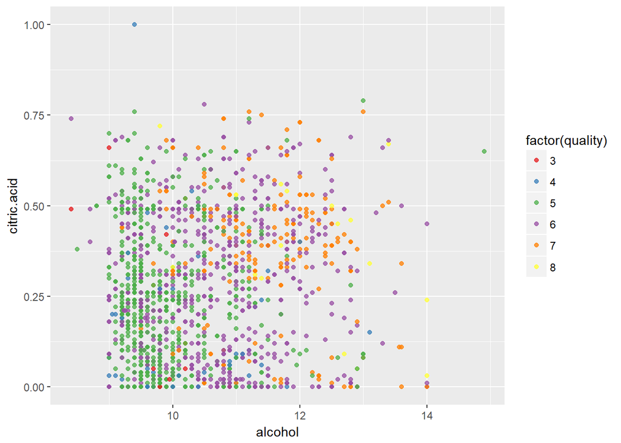

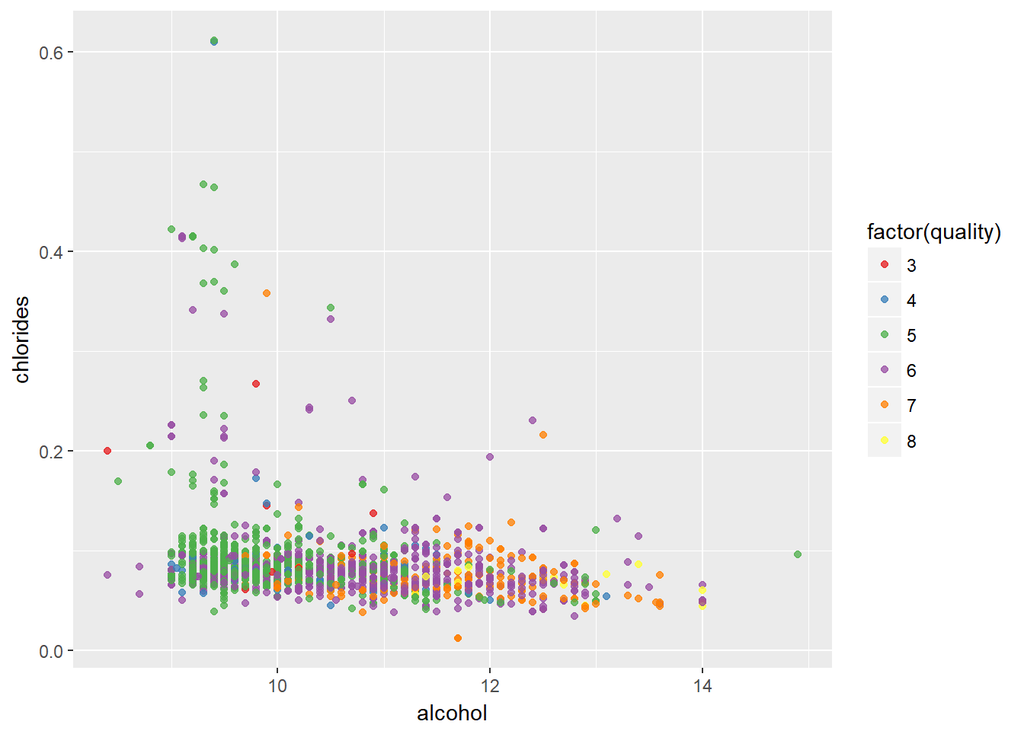

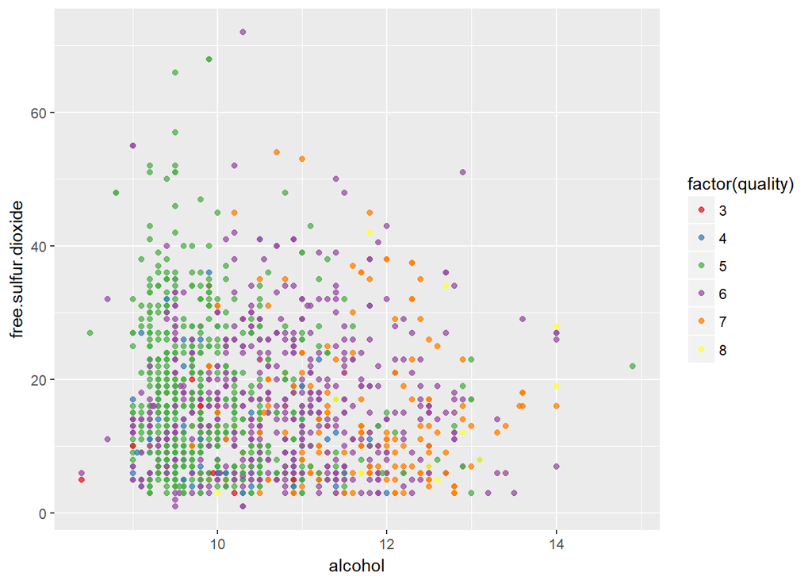

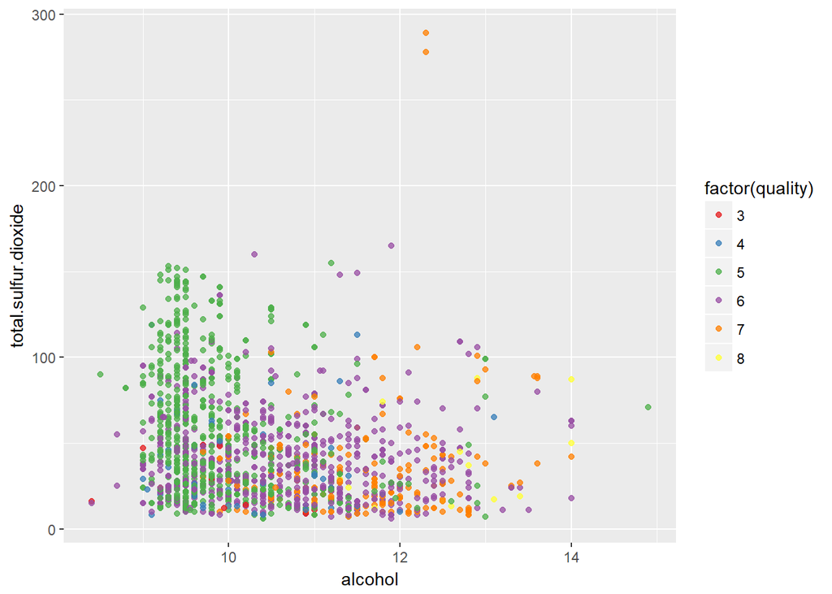

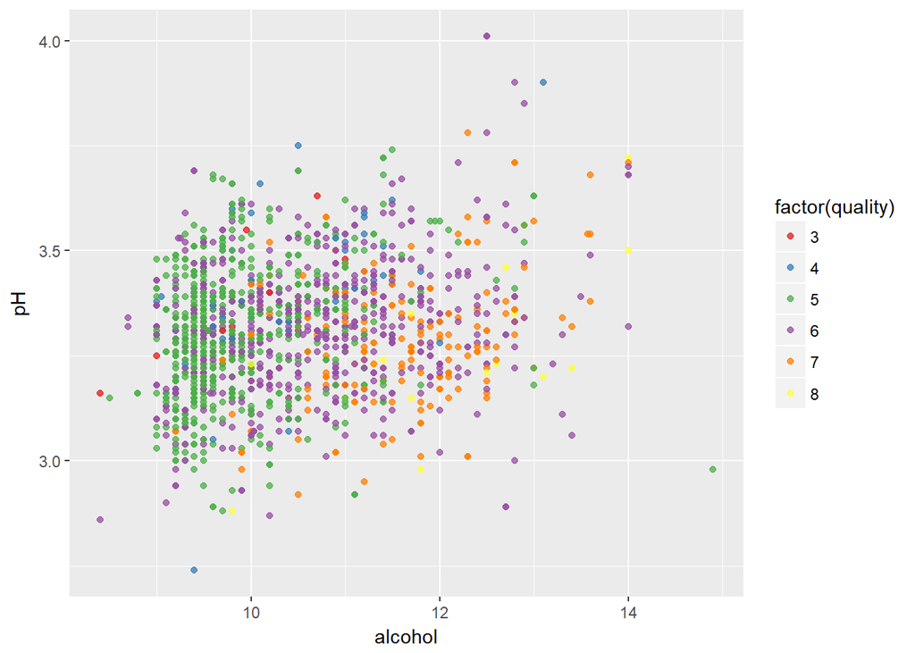

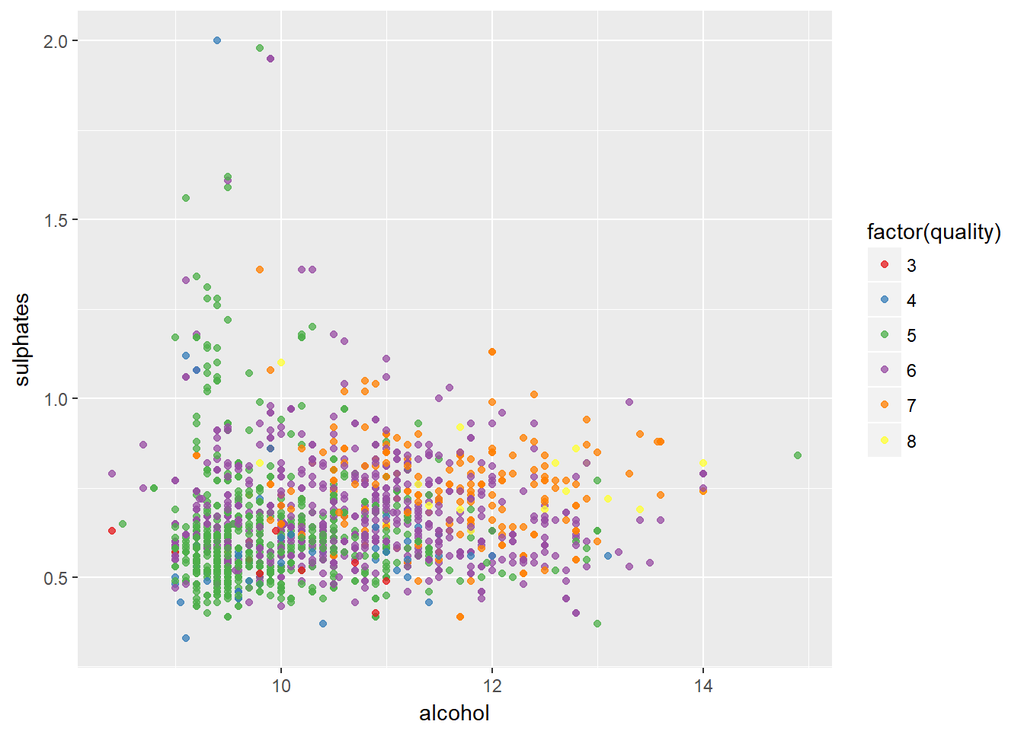

No concrete conclusions can be made by the above scatter plot analysis

### Scatter plot analysis of volatile acidity vs quality

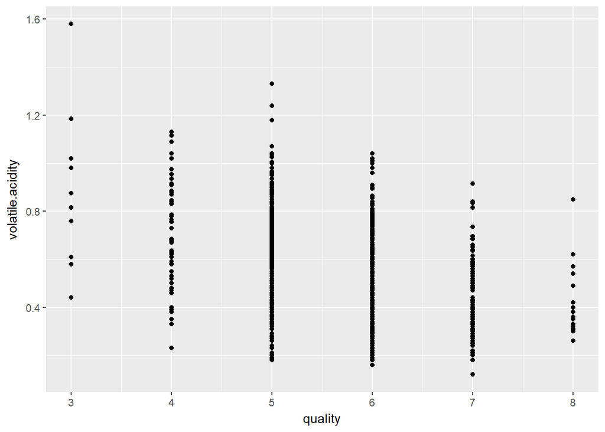

### Box plot of volatile acidity vs quality

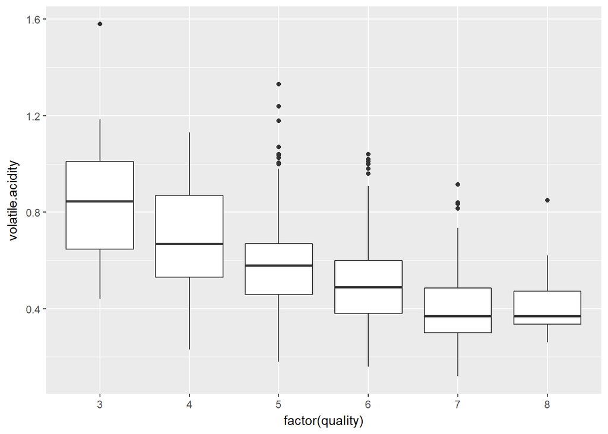

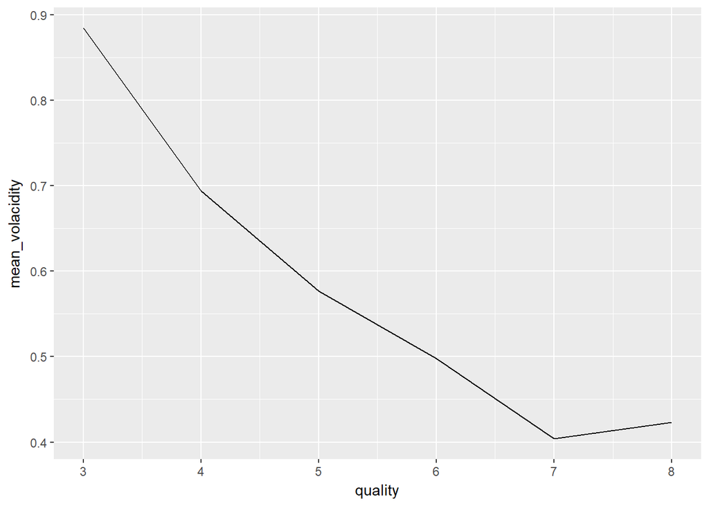